# Lab 2 - Checkpoint 1

Joab de Araújo

16 de abril de 2018

```r
suppressMessages(library("tidyverse"))
suppressMessages(library("here"))
suppressMessages(library("ggplot2"))
library(tidyverse)
library(here)
library(knitr)
library(ggplot2)
library(dplyr)
theme_set(theme_bw())
```

# **Descrevendo as variáveis utilizadas**

```r
checkpoint1 = read_csv(here::here("data/projetos.csv"))
```

```r
checkpoint1 = checkpoint1 %>%
    filter(lang != "javascript")
```

Nesse relatório serão apresentado os resultados obtidos, para responder a seguinte pergunta:

1. Existe alguma relação entre o tamanho do time e o número de commits e builds por mês?

Para responder a pergunta foram utilizados as variáveis:

- **commits_per_month**: É a média mensal de commits;
- **team**: Tamanho do time(número de desenvolvedores) de cada projeto;
- **builds_per_month**: É a média mensal de builds;
- **lang**: Linguagem predominante do projeto.

Essas variáveis foram obtidas do site [TravisTorrent](https://travistorrent.testroots.org/) e toda a análise dos dados foi feito usando a linguagem R.

Para isso 6 gráficos distintos foram elaborados para ver qual gráfico melhor responderia essa pergunta. Cada gráfico será enumerado para facilitar o detalhamento mais à frente.

## **Gráfico 1**

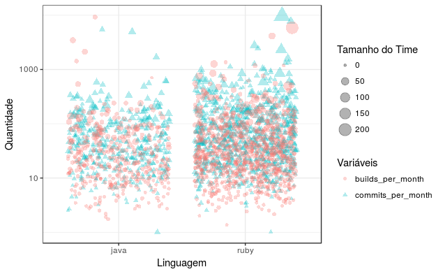

```r
projetos = checkpoint1 %>% gather(quant_type, quant, commits_per_month, builds_per_month)
projetos %>%
    ggplot(aes(x = lang, y = quant)) +
    labs(x = "Linguagem", y = "Quantidade", color = "Variáveis", shape = "Variáveis", size = "Tamanho do Time") +
    geom_jitter(aes(color = quant_type, shape = quant_type, size = team), alpha = 0.3) +
    scale_y_log10()
```

## **Gráfico 2**

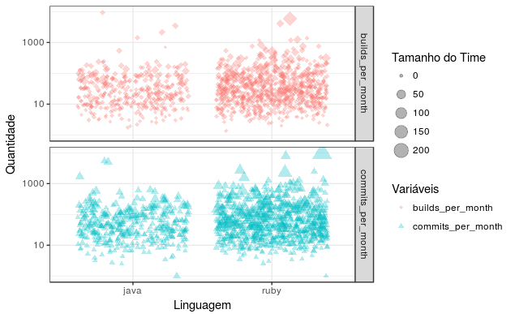

```r
projetos = checkpoint1 %>% gather(quant_type, quant, commits_per_month, builds_per_month)
projetos %>%
    ggplot(aes(x = lang, y = quant)) +
    labs(x = "Linguagem", y = "Quantidade", color = "Variáveis", shape = "Variáveis", size = "Tamanho do Time") +
    facet_grid(quant_type ~ .)+
    geom_jitter(aes(color = quant_type, shape = quant_type, size = team), alpha = 0.3) +
    scale_shape_manual(values=c(18,17))+
    scale_y_log10()
```

## **Gráfico 3**

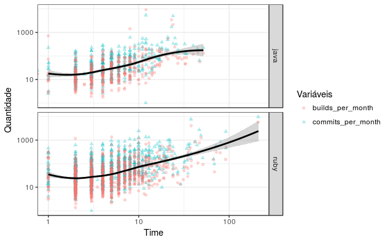

```r
projetos = checkpoint1 %>% gather(quant_type, quant, commits_per_month, builds_per_month)
projetos %>%
    ggplot(aes(x = team, y = quant)) +
    labs(x = "Time", y = "Quantidade", color = "Variáveis", shape = "Variáveis") +
    facet_grid(lang ~ .) +
    geom_jitter(aes(color = quant_type, shape = quant_type), alpha = 0.3) +
    geom_smooth(method = 'loess', colour="black")+
    scale_y_log10() +
    scale_x_log10()
```

## **Gráfico 4**

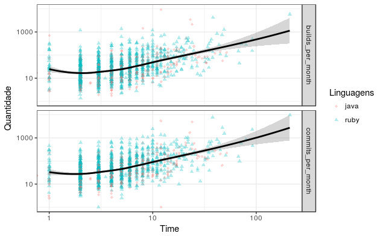

```r
projetos = checkpoint1 %>% gather(quant_type, quant, commits_per_month, builds_per_month)
projetos %>%
    ggplot(aes(x = team, y = quant)) +
    labs(x = "Time", y = "Quantidade", color = "Linguagens", shape = "Linguagens") +
    facet_grid(quant_type ~ .) +
    geom_jitter(aes(color = lang, shape = lang),alpha = 0.3) +
    scale_shape_manual(values=c(18,17))+
    geom_smooth(method = 'loess', colour="black")+
    scale_y_log10() +
    scale_x_log10()
```

## **Gráfico 5**

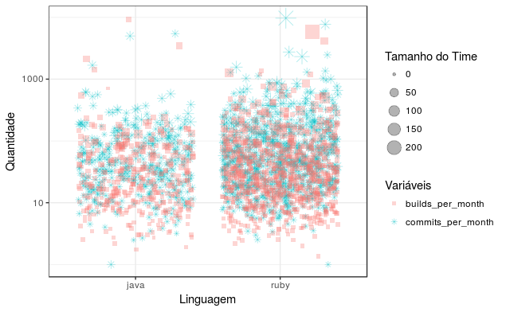

```r
projetos = checkpoint1 %>% gather(quant_type, quant, commits_per_month, builds_per_month)
projetos %>%
    ggplot(aes(x = lang, y = quant)) +
    labs(x = "Linguagem", y = "Quantidade", color = "Variáveis", shape = "Variáveis", size = "Tamanho do Time") +
    geom_jitter(aes(color = quant_type, shape = quant_type, size = team), alpha = 0.3) +
    scale_shape_manual(values=c(15,8))+
    scale_y_log10()
```

## **Gráfico 6**

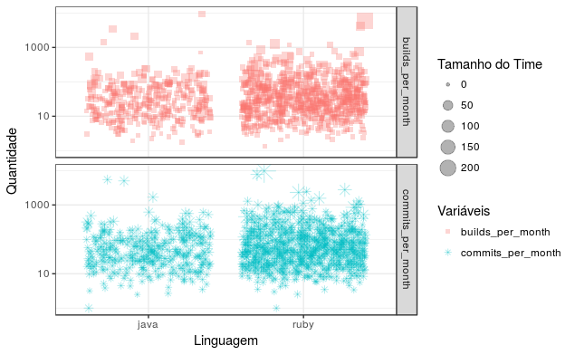

```r
projetos = checkpoint1 %>% gather(quant_type, quant, commits_per_month, builds_per_month)
projetos %>%
    ggplot(aes(x = lang, y = quant)) +
    labs(x = "Linguagem", y = "Quantidade", color = "Variáveis", shape = "Variáveis", size = "Tamanho do Time") +
    facet_grid(quant_type ~ .)+
    geom_jitter(aes(color = quant_type, shape = quant_type, size = team), alpha = 0.3) +
    scale_shape_manual(values=c(15,8))+
    scale_y_log10()
```

## **Respondendo a pergunta**

No aspecto de melhor visualização para a resposta, dois gráficos se destacaram mais, que foram os gráficos 2 e 4.

O gráfico 4 ajudado pela função [geom_smooth](http://ggplot2.tidyverse.org/reference/geom_smooth.html), em que a linha indica a média, mostra que a medida que os times vão crescendo, a média tanto de commits, quanto de builds também aumenta. Além disso pode ser observado que a maioria dos pontos no gráfico, se concentram abaixo de 1000(commits e builds por mês) enquanto os time tem tamanho até 10, e após isso há um leve aumento da média e a medida que o tamanho dos times aumenta, mais pontos são registrados nos valores acima de 1000.

O gráfico 2 também é uma boa opção devido ao tamanho das formas dos pontos. Não consegue ser tão claro a observação como no gráfico 4, porém percebe-se o maior número de formas maiores dos pontos nos valores acima de 1000, com isso pode-se inferir que também quanto maior são os times, maiores são o número de builds e commits por mês.